# STAT545_hmk2_WilliamHall

William Hall

2018-09-18

## Smell Test the data

> Is gapminder a data.frame, a matrix, a vector, a list? What is gapminder’s class?

```r
str(gapminder)
```

```
## Classes 'tbl_df', 'tbl' and 'data.frame':    1704 obs. of  6 variables:
##  $ country  : Factor w/ 142 levels "Afghanistan",..: 1 1 1 1 1 1 1 1 1 1 ...
##  $ continent: Factor w/ 5 levels "Africa","Americas",..: 3 3 3 3 3 3 3 3 3 3 ...
##  $ year     : int  1952 1957 1962 1967 1972 1977 1982 1987 1992 1997 ...
##  $ lifeExp  : num  28.8 30.3 32 34 36.1 ...
##  $ pop      : int  8425333 9240934 10267083 11537966 13079460 14880372 12881816 13867957 16317921 22227415 ...
##  $ gdpPercap: num  779 821 853 836 740 ...
```

Using str(), we can see that gapminder has multiple classes ‘tbl_df’, ‘tbl’, and ‘data.frame’. I think this means that it is a tibble/data frame.

> How many variables/columns does gapminder have? How many rows/observations does gapminder have?

Gapminder has 1704 rows, and 6 columns.

> Can you get these facts about “extent” or “size” in more than one way? Can you imagine different functions being useful in different contexts?

Yup. You could use anyone of the following functions to get information about the dataset. - names() - head() - summary() - str() - nrow() - ncol()

> What data type is each variable?
- Country is a factor variable.
- Continent is a factor variable.
- Year is a integer variable.
- Life Expectancy is a numeric variable.
- Population is a integer variable.
- GDP is a numeric variable.

## ‘Life Expectancy’ Continuous Variable Exploration

- What are possible values (or range, whichever is appropriate) of each variable?
- What values are typical? What’s the spread? What’s the distribution?

```r
summary(gapminder$lifeExp)
```

```
##    Min. 1st Qu.  Median    Mean 3rd Qu.    Max.
##   23.60   48.20   60.71   59.47   70.85   82.60
```

- The minimum value of Life Expectancy is 23.599.
- The maximum value of Life Expectancy is 82.603.
- The median value. of Life Expectancy is 60.7125.
- The mean value. of Life Expectancy is 59.4744394.

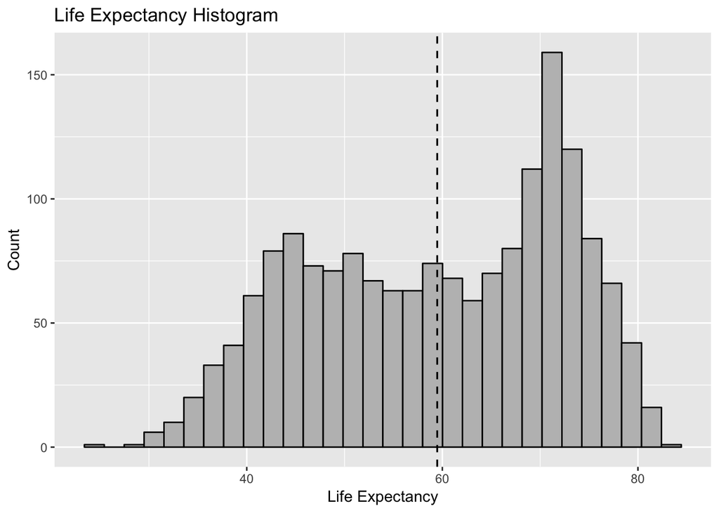

```r
ggplot(data=gapminder, aes(x=gapminder$lifeExp)) +
         geom_histogram(bins = 30, color = "black", fill = "gray") +
         geom_vline(aes(xintercept = mean(gapminder$lifeExp)),
             linetype = "dashed", size = 0.6) +
         xlab("Life Expectancy") +
         ylab("Count") +
         ggtitle("Life Expectancy Histogram")
```

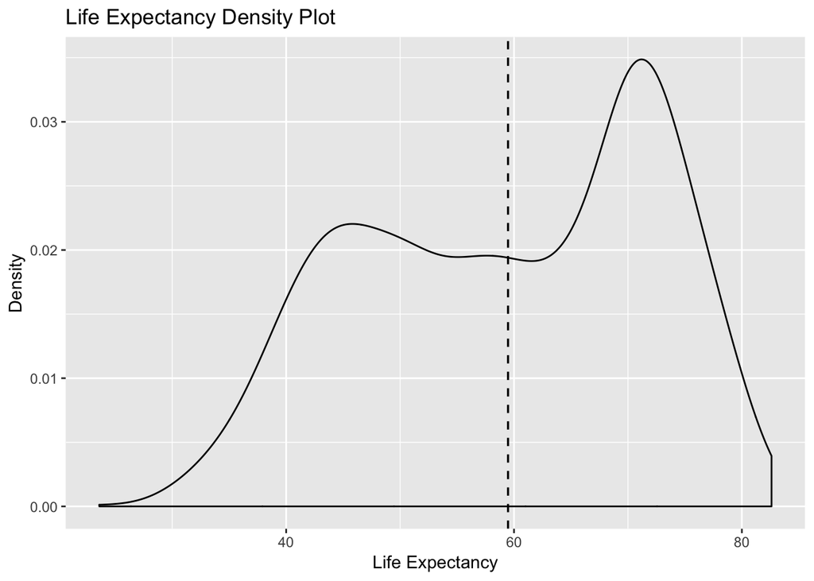

```r
ggplot(gapminder, aes(x=gapminder$lifeExp)) +
  geom_density() +
  geom_vline(aes(xintercept = mean(gapminder$lifeExp)),
             linetype = "dashed", size = 0.6) +
  xlab("Life Expectancy") +
  ylab("Density") +
  ggtitle("Life Expectancy Density Plot")
```

## ‘Continent’ Categorical Variable Exploration

The Contient variable in the Gapminder dataset is a factor variable. It has the following levels Africa, Americas, Asia, Europe, Oceania.

```r
levels(gapminder$continent)
```

```
## [1] "Africa"   "Americas" "Asia"     "Europe"   "Oceania"
```

The following describes the frequency of each level.

```r
summary(gapminder$continent)
```

```
##   Africa Americas     Asia   Europe  Oceania
##      624      300      396      360       24
```

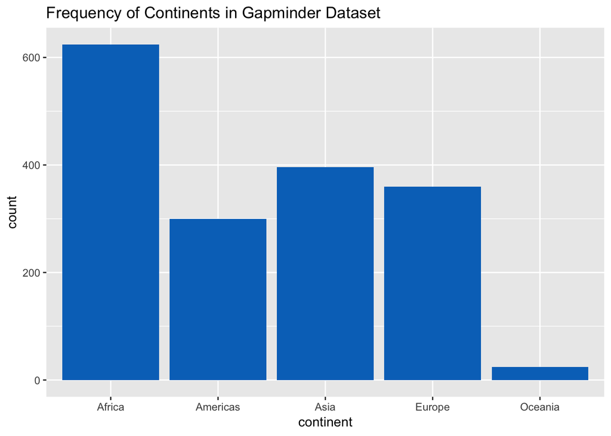

```r
ggplot(gapminder, aes(continent)) +
  geom_bar(fill = "#0073C2FF") +
  ggtitle("Frequency of Continents in Gapminder Dataset")
```

## Explore Plotting

> Scatterplot of two quantitative variables

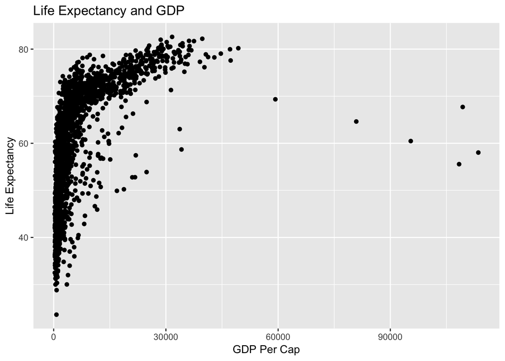

```r
ggplot(gapminder, aes(x=gdpPercap, y=lifeExp)) +
  geom_point() +
  xlab("GDP Per Cap") +
  ylab("Life Expectancy") +
  ggtitle("Life Expectancy and GDP")
```

> Plot of one quantitative variable

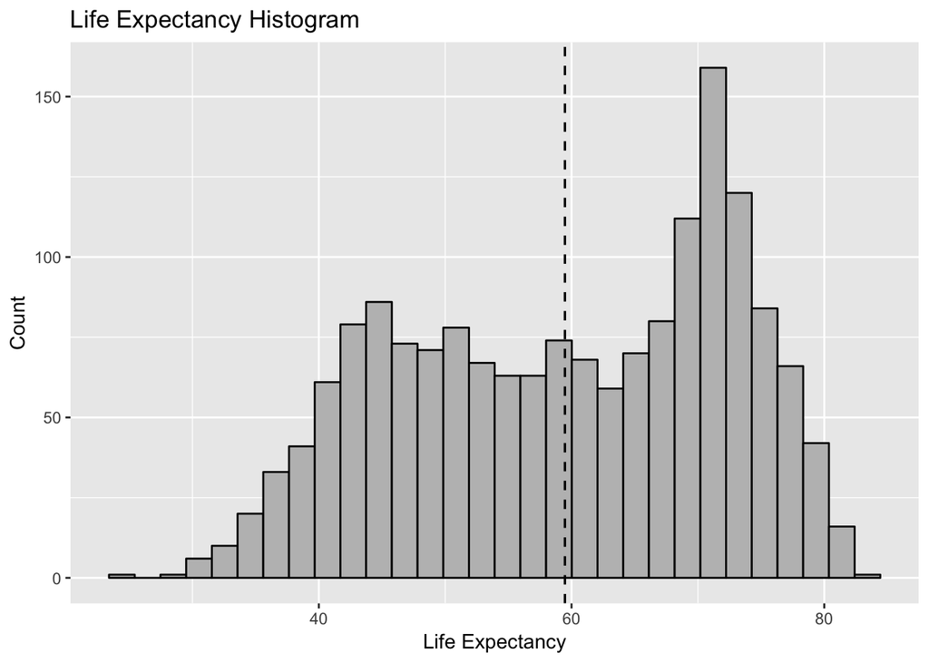

```r
ggplot(data=gapminder, aes(x=gapminder$lifeExp)) +
         geom_histogram(bins = 30, color = "black", fill = "gray") +
         geom_vline(aes(xintercept = mean(gapminder$lifeExp)),
             linetype = "dashed", size = 0.6) +
         xlab("Life Expectancy") +
         ylab("Count") +
         ggtitle("Life Expectancy Histogram")
```

> Plot of one quantitative and one categorical variable

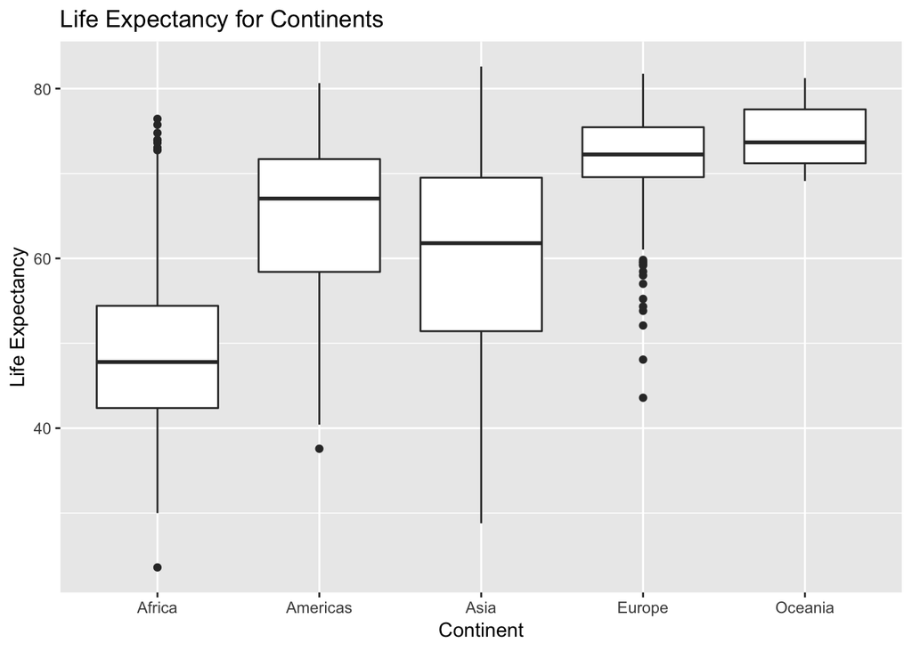

```r
ggplot(gapminder, aes(continent, lifeExp)) +
  geom_boxplot() +
  xlab("Continent") +
  ylab("Life Expectancy") +
  ggtitle("Life Expectancy for Continents")
```

## Show me your PIPES

> So what if we wanted to compare the mean GDP for countries in Africa with life expectancy.

This first set of code will create a new data set that will provide the mean life expectancy for each country in Africa as well as its GPD per capita.

```r
gapminder %>%
    filter(continent == "Africa") %>%
    group_by(country) %>%
    summarize(Mean.Life = mean(lifeExp), GDP = mean(gdpPercap))
```

```
## # A tibble: 52 x 3
##    country                  Mean.Life   GDP
##    <fct>                        <dbl> <dbl>
##  1 Algeria                       59.0 4426.
##  2 Angola                        37.9 3607.
##  3 Benin                         48.8 1155.
##  4 Botswana                      54.6 5032.
##  5 Burkina Faso                  44.7  844.
##  6 Burundi                       44.8  472.
##  7 Cameroon                      48.1 1775.
##  8 Central African Republic      43.9  959.
##  9 Chad                          46.8 1165.
## 10 Comoros                       52.4 1314.
## # ... with 42 more rows
```

This second set of data will graph the same information using points.

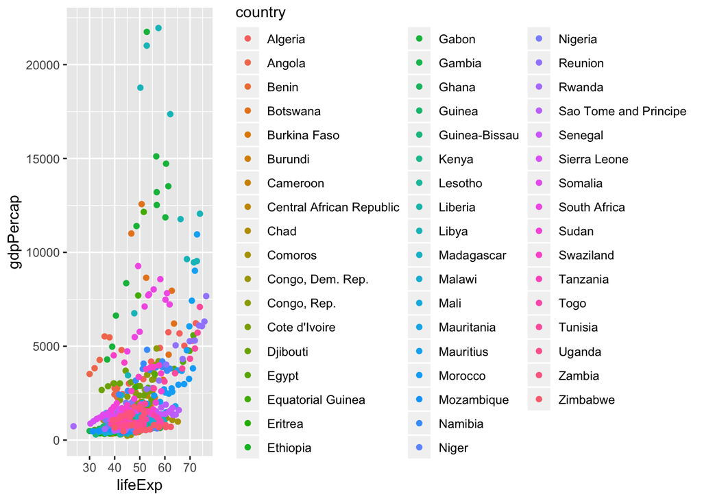

```r
gapminder %>%
  filter(continent == "Africa") %>%
  ggplot(aes(lifeExp, gdpPercap)) +
  geom_point(aes(col = country))
```

## But I want to do more!

> filter(gapminder, country == c(“Rwanda”, “Afghanistan”))

I think what they want to do is look at all the variables in the data for only Rwanda and Afghanistan. The code below should do that.

```r
A.AData <- gapminder %>%
                filter(country == "Rwanda" | country == "Afghanistan")
```

## Reflection

This assignment was fun. One thing I struggle with is the %>% pipe vs. the + for ggpplot. I figured it out eventually, but I definitely lost some hair trying to figure out what was wrong with my code. I can see how the tidyverse is super powerful, and why everyone loves it so much :)

Can’t wait to dig into some more of the advanced features!

Some useful resources:

- https://www.datacamp.com/courses/data-visualization-with-ggplot2-1
- https://www.rstudio.com/wp-content/uploads/2015/02/data-wrangling-cheatsheet.pdf